# Spatial Training

# Introduction to Spatial in R

Vector spatial data

- `sp`/`rgdal` - closely linked packages, used when working with spatial files (e.g. read/write spatial data, transform coordinate system)
- `regeos` - can merge polygons and use the buffer and intersect operations
- `sf` - can treat spatial data as a data frame and use similar approaches to manipulating data; sometimes need to transform back to shapefile format but may eventually replace `sp` and `rgeos`; can’t interact with rasters though - need to convert back to shapefile

Raster spatial data

- `raster` - primarily used for raster manipulation (read/write, manipulate, transform, analyze, modeling)
- `fasterize` - converts vector data into a raster (similar to raster::rasterize, which is slower)
- `rgdal` - used for projections

[spatial R script for OHI](https://github.com/OHI-Science/ohiprep_v2018/blob/bccb633f6e147142e814eae4a84f81a572b2d369/src/R/spatial_common.R) [rspatial on twitter](https://twitter.com/hashtag/rspatial)

# Projections

- Can’t really preserve both direction and distance/area simultaneously (trade-offs!)
- Lat/Long is considered unprojected data; most common for global data, but not great for very localized data (e.g. 1-m resolution)
- Mollweide represents area more accurately; most common for OHI global assessments; direction not accurately represent, but not important for OHI; not commonly used in the general community (people might not be familiar)
- Data must be in same projection: specify with epsg code or proj4string

Vector spatial data

- Retrieve projection - `proj4spring(x)`
- Describe/define projection - `proj4spring(x) <- CRS("+init=epsg:28992")` OR `proj4spring(x) <- CRS("+proj=moll +ellps=WGS84")`
- If need to transform from one CRS projection to another, can use `spTransform(x, CRS("..."))`

Raster spatial data

- Retrieve - `projection(x)`
- Describe - `projection(x) <- CRS("...")`
- Transform - `projectRaster()`

# Exploring `sf` (simple features) Package

See [Jamie’s training doc](https://rawgit.com/jafflerbach/spatial-analysis-R/gh-pages/intro_to_sf.html).

## Load Packages

```r
## install packages
# install.packages(c("sf","raster","rgdal"))

## load packages using library()
library(tidyverse) #devtools::install_github("tidyverse/ggplot2") ## if most recent vers. not in CRAN
library(sp)
library(rgdal)
library(sf)
library(raster) # allows you to print out shapefiles with a more condensed summary rather than the full-length list; dplyr and raster may have conflicts
# select <- dplyr::select ## this code will force select() to be used from the dplyr package not raster package
```

## 1. Load shapefile using `rgdal`

```r
setwd("../spatial-analysis-R/")

west_shp_rgdal <- rgdal::readOGR(dsn = "shapefiles", layer = "wc_regions")
```

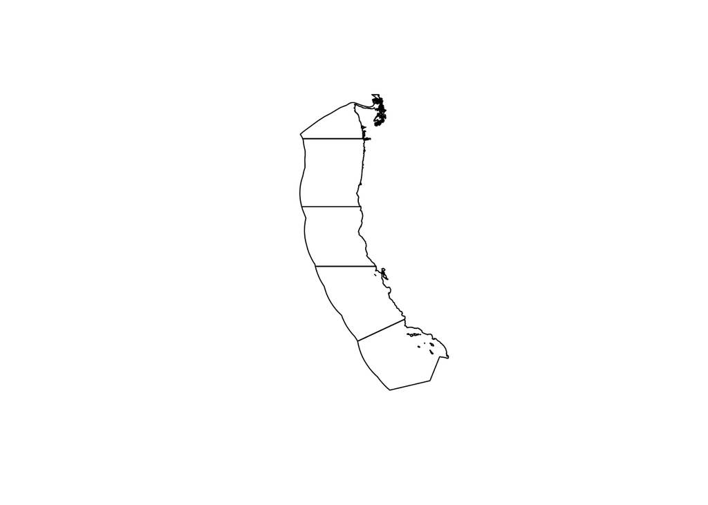

```r
## Take a look in a plot
plot(west_shp_rgdal)
```

```r
## Check the class of the object is SpatialPolygonsDataFrame
west_shp_rgdal
```

```
## class       : SpatialPolygonsDataFrame
## features    : 5
## extent      : -129.1635, -117.097, 30.542, 49.00031  (xmin, xmax, ymin, ymax)
## coord. ref. : +proj=longlat +datum=WGS84 +no_defs +ellps=WGS84 +towgs84=0,0,0
## variables   : 3
## names       :                rgn, rgn_key,      area_m2
## min values  : Central California,    CA-C, 164378809215
## max values  :         Washington,      WA,  66898309678
```

## 2. Load shapefile using `sf`

- Will print out some of the data table associated with the shapefile
- With an sf object always subset for 1 column when plotting so R doesn’t crash if it’s huge

```r
setwd("../spatial-analysis-R/")
west_shp_sf <- st_read(dsn = "shapefiles", layer = "wc_regions")
west_shp_sf
```

```
## Simple feature collection with 5 features and 3 fields
## geometry type:  MULTIPOLYGON
## dimension:      XY
## bbox:           xmin: -129.1635 ymin: 30.542 xmax: -117.097 ymax: 49.00031
## epsg (SRID):    4326
## proj4string:    +proj=longlat +datum=WGS84 +no_defs
##                   rgn rgn_key      area_m2                       geometry
## 1              Oregon      OR 179994061293 MULTIPOLYGON (((-123.4318 4...
## 2 Northern California    CA-N 164378809215 MULTIPOLYGON (((-124.2102 4...
## 3  Central California    CA-C 202738329147 MULTIPOLYGON (((-122.9928 3...
## 4 Southern California    CA-S 206860777840 MULTIPOLYGON (((-120.6505 3...
## 5          Washington      WA  66898309678 MULTIPOLYGON (((-122.7675 4...
```

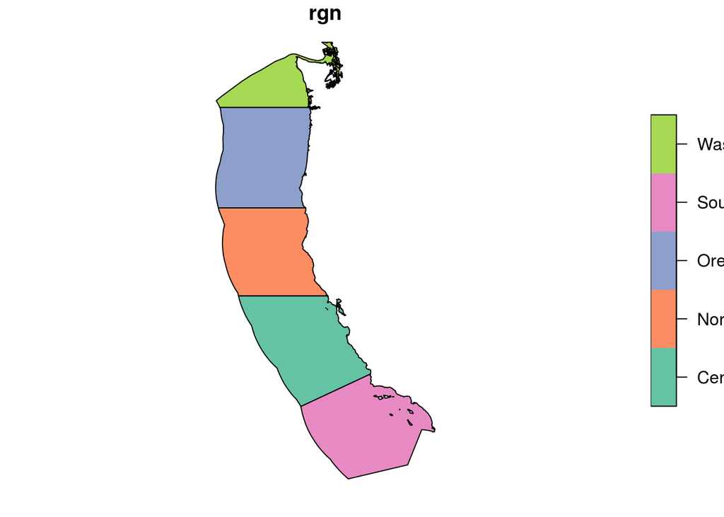

```r
plot(west_shp_sf[1])
```

```r
nrow(west_shp_sf)
```

```
## [1] 5
```

## `sf` and `dplyr`

```r
## remove a column using sf & dplyr
west_shp_sf %>%
  dplyr::select(rgn, rgn_key) # geometry column is always preserved, but removes 'area_m2'
```

```
## Simple feature collection with 5 features and 2 fields
## geometry type:  MULTIPOLYGON
## dimension:      XY
## bbox:           xmin: -129.1635 ymin: 30.542 xmax: -117.097 ymax: 49.00031
## epsg (SRID):    4326
## proj4string:    +proj=longlat +datum=WGS84 +no_defs
##                   rgn rgn_key                       geometry
## 1              Oregon      OR MULTIPOLYGON (((-123.4318 4...
## 2 Northern California    CA-N MULTIPOLYGON (((-124.2102 4...
## 3  Central California    CA-C MULTIPOLYGON (((-122.9928 3...
## 4 Southern California    CA-S MULTIPOLYGON (((-120.6505 3...
## 5          Washington      WA MULTIPOLYGON (((-122.7675 4...
```

```r
## filter
west_shp_sf %>%
  dplyr::filter(rgn == "Oregon")
```

```
## Simple feature collection with 1 feature and 3 fields
## geometry type:  MULTIPOLYGON
## dimension:      XY
## bbox:           xmin: -129.1635 ymin: 41.9984 xmax: -123.4318 ymax: 46.271
## epsg (SRID):    4326
## proj4string:    +proj=longlat +datum=WGS84 +no_defs
##      rgn rgn_key      area_m2                       geometry
## 1 Oregon      OR 179994061293 MULTIPOLYGON (((-123.4318 4...
```

```r
## Create new two new columns with mutate
sf_out <- west_shp_sf %>%
  mutate(rgn_id = c(1:5),
         area_km2 = area_m2/1000000)
```

## Transform spatial data in `sf`

- Currently sf_out is in lat/long format
- Let’s reproject sf_out to Mollweid

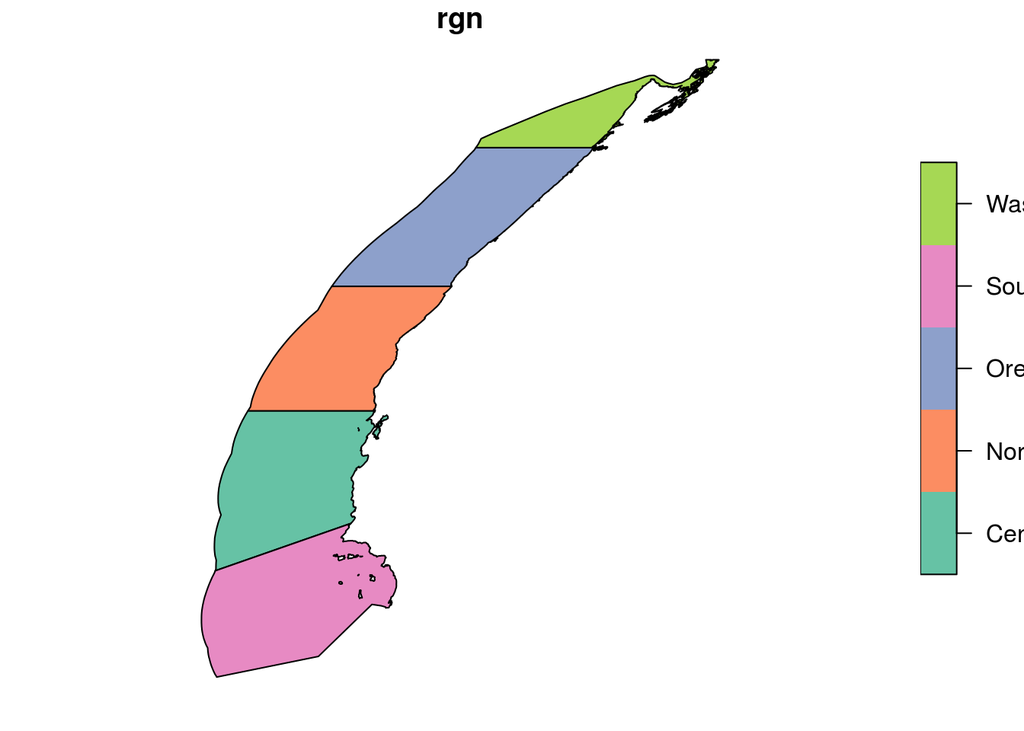

```r
sf_trans <- st_transform(sf_out, crs = "+proj=moll +ellps=WGS84")
plot(sf_trans[1])
```

## Save simple feature

```r
setwd("../spatial-analysis-R/")
st_write(sf_out, "shapefiles/wc_regions_clean.shp", driver = "ESRI Shapefile", delete_layer = TRUE) # delete_layer lets you overwrite the file if it already exists and replace it
```

```
## Deleting layer `wc_regions_clean' using driver `ESRI Shapefile'
## Writing layer `wc_regions_clean' to data source `/home/isu/github/spatial-analysis-R/shapefiles/wc_regions_clean.shp' using driver `ESRI Shapefile'
## features:       5
## fields:         5
## geometry type:  Multi Polygon
```

## Visualize with ggplot

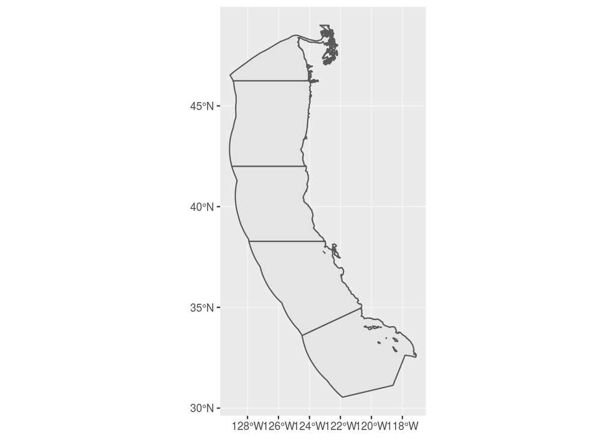

```r
ggplot(sf_out) +
  geom_sf()
```

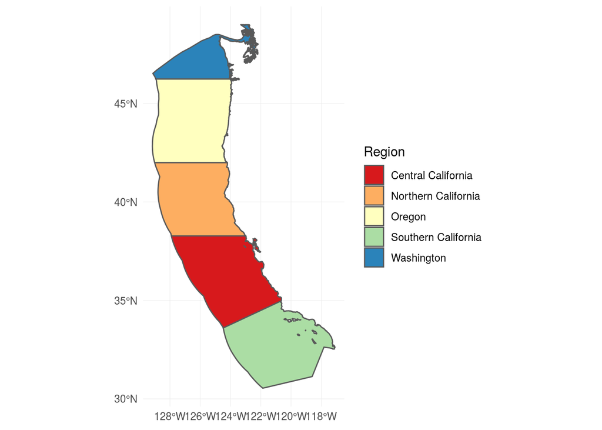

```r
## Plot and fill with a discrete variable
ggplot(sf_out) +
  geom_sf(aes(fill = rgn)) + # rgn is discrete variable
  theme_minimal() +
  labs(fill = "Region") + # this changes the legend title to "Region"
  scale_fill_brewer(palette = "Spectral")
```

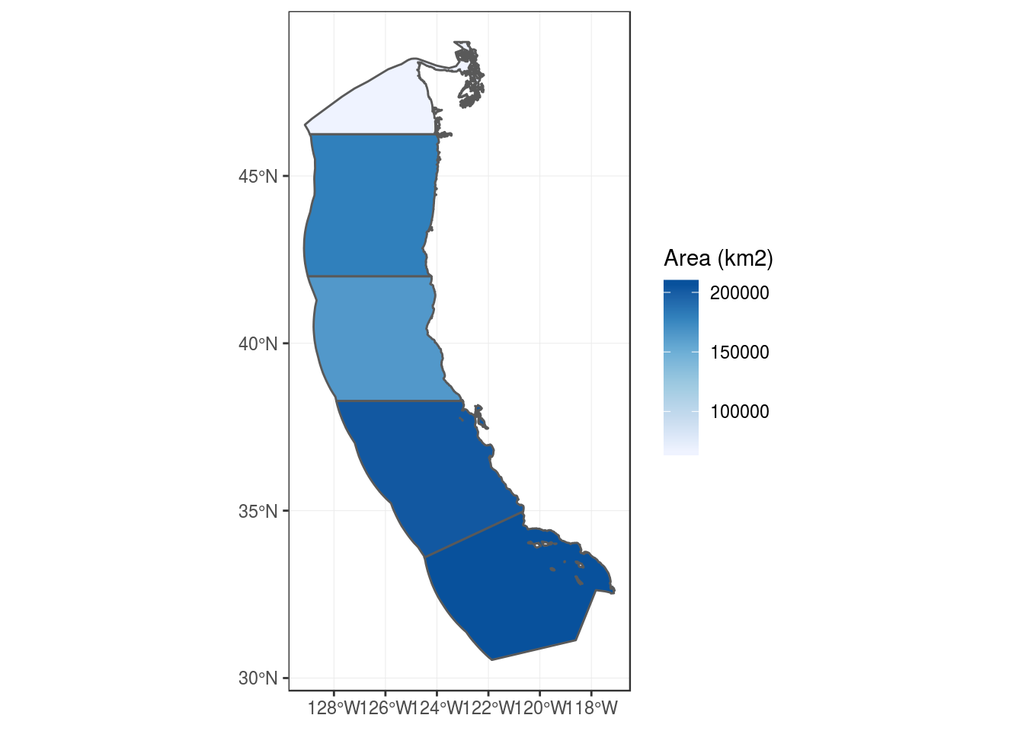

```r
## Plot and fill with a continuous variable
ggplot(sf_out) +
  geom_sf(aes(fill = area_km2)) + # area is continuous variable
  theme_bw() +
  labs(fill = "Area (km2)") +
  scale_fill_distiller(palette = "Blues", direction=1) #direction can be used to reverse the color palette scale; try changing value to '-1"
```

## Use `st_union` to combine polygons

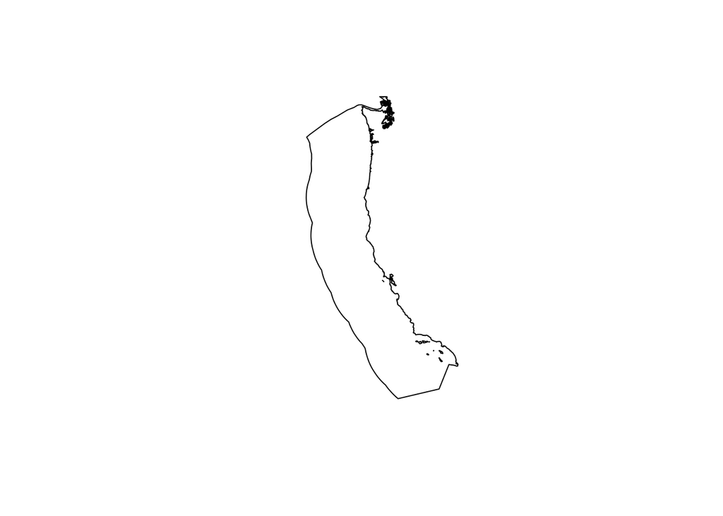

```r
full_rgn <- st_union(sf_out)
plot(full_rgn[1])
```